# Case Solution Group 5

Balint Keller, Ling-Fei Chen , Elisabeth Bonte, Lieke Vanhaverbeke, Stef Desender, Seppe Van Campe

2025-04-25

# **1. Empirical Specification and Hypotheses**

Baseline model:

$$WAGE_i = \beta_1 + \beta_2 \, EDUCi +
\alpha \, X_i + \mu_i$$

Where Xi includes AGE, RACE, MARRIED, SMSA, and REGION.

## **Hypothesis Tests:**

##### **EDUC: Education**

H0: B2 $\leq$ 0 → Education has no or a negative effect on wages.

H1: B2 $>$ 0 → Education has a positive effect on wages.

One-sided test: Economic theory predicts that more education increases wages, so a negative effect would be counterintuitive.

##### **AGE: Age**

H0: A(AGE) $\leq$ 0 → Age has no or a negative effect on wages.

H1: A(AGE) $>$ 0 → Age has a positive effect on wages.

One-sided test: Age is often associated with experience, which is expected to increase wages.

##### **MARRIED: Marital Status**

H0: A(MARRIED) $\leq$ 0 → Being married has no or a negative effect on wages.

H1: A(MARRIED) $>$ 0 → Being married has a positive effect on wages.

One-sided test: Being married may indicate stability and a positive impact on productivity, leading to higher wages.

##### **SMSA: Metropolitan Area**

H0: A(SMSA) $\leq$ 0 → Living in a metropolitan area has no or a negative effect on wages.

H1: A(SMSA) $>$ 0 → Living in a metropolitan area has a positive effect on wages.

One-sided test: Urban areas typically have more job opportunities and higher wages, driving this expectation.

##### **RACE: Race (1 = Black, 0 = White)**

H0: A(RACE) $\geq$ 0 → Race has no or a positive effect on wages.

H1: A(RACE) $<$ 0 → Race has a negative effect on wages.

One-sided test: Structural inequalities often result in lower wages for minority groups.

##### **REGION: Geographic Region**

H1: A(REGION) $=$ 0 → (At least one region has a positive effect on wages.)

Two-sided test: Region could impact wages in either direction

# **2. Explore the Data**

```r
head(df)
```

|  | WAGE | EDUC | AGE | RACE | SMSA | MARRIED | REGION | QOB | REGION1 | REGION2 | REGION3 | REGION4 | REGION5 | REGION6 | REGION7 | REGION8 | REGION9 | QOB1 | QOB2 | QOB3 | QOB4 |
| --- | --- | --- | --- | --- | --- | --- | --- | --- | --- | --- | --- | --- | --- | --- | --- | --- | --- | --- | --- | --- | --- |
| 1 | 580.1000 | 9 | 45 | 0 | 0 | 1 | 9 | 3 | 0 | 0 | 0 | 0 | 0 | 0 | 0 | 0 | 1 | 0 | 0 | 1 | 0 |
| 2 | 642.2115 | 17 | 47 | 0 | 0 | 1 | 3 | 4 | 0 | 0 | 1 | 0 | 0 | 0 | 0 | 0 | 0 | 0 | 0 | 0 | 1 |
| 3 | 577.0192 | 12 | 42 | 0 | 0 | 1 | 7 | 2 | 0 | 0 | 0 | 0 | 0 | 0 | 1 | 0 | 0 | 0 | 1 | 0 | 0 |
| 4 | 999.1346 | 10 | 43 | 0 | 0 | 1 | 3 | 2 | 0 | 0 | 1 | 0 | 0 | 0 | 0 | 0 | 0 | 0 | 1 | 0 | 0 |
| 5 | 307.7885 | 12 | 41 | 0 | 0 | 1 | 6 | 3 | 0 | 0 | 0 | 0 | 0 | 1 | 0 | 0 | 0 | 0 | 0 | 1 | 0 |
| 6 | 280.1000 | 12 | 40 | 1 | 0 | 1 | 5 | 2 | 0 | 0 | 0 | 0 | 1 | 0 | 0 | 0 | 0 | 0 | 1 | 0 | 0 |

```r
summary(df)
```

```
##       WAGE                EDUC            AGE             RACE
##  Min.   :    0.096   Min.   : 0.00   Min.   :40.00   Min.   :0.0000
##  1st Qu.:  278.558   1st Qu.:12.00   1st Qu.:42.00   1st Qu.:0.0000
##  Median :  384.712   Median :12.00   Median :45.00   Median :0.0000
##  Mean   :  436.524   Mean   :12.71   Mean   :44.68   Mean   :0.0832
##  3rd Qu.:  520.100   3rd Qu.:15.00   3rd Qu.:47.00   3rd Qu.:0.0000
##  Max.   :10167.500   Max.   :20.00   Max.   :50.00   Max.   :1.0000
##       SMSA           MARRIED           REGION           QOB
##  Min.   :0.0000   Min.   :0.0000   Min.   :1.000   Min.   :1.000
##  1st Qu.:0.0000   1st Qu.:1.0000   1st Qu.:3.000   1st Qu.:1.000
##  Median :0.0000   Median :1.0000   Median :5.000   Median :3.000
##  Mean   :0.1813   Mean   :0.8609   Mean   :4.767   Mean   :2.502
##  3rd Qu.:0.0000   3rd Qu.:1.0000   3rd Qu.:7.000   3rd Qu.:3.000
##  Max.   :1.0000   Max.   :1.0000   Max.   :9.000   Max.   :4.000
##     REGION1          REGION2          REGION3          REGION4
##  Min.   :0.0000   Min.   :0.0000   Min.   :0.0000   Min.   :0.0000
##  1st Qu.:0.0000   1st Qu.:0.0000   1st Qu.:0.0000   1st Qu.:0.0000
##  Median :0.0000   Median :0.0000   Median :0.0000   Median :0.0000
##  Mean   :0.0549   Mean   :0.1584   Mean   :0.1949   Mean   :0.0732
##  3rd Qu.:0.0000   3rd Qu.:0.0000   3rd Qu.:0.0000   3rd Qu.:0.0000
##  Max.   :1.0000   Max.   :1.0000   Max.   :1.0000   Max.   :1.0000
##     REGION5          REGION6         REGION7          REGION8
##  Min.   :0.0000   Min.   :0.000   Min.   :0.0000   Min.   :0.0000
##  1st Qu.:0.0000   1st Qu.:0.000   1st Qu.:0.0000   1st Qu.:0.0000
##  Median :0.0000   Median :0.000   Median :0.0000   Median :0.0000
##  Mean   :0.1773   Mean   :0.064   Mean   :0.0995   Mean   :0.0494
##  3rd Qu.:0.0000   3rd Qu.:0.000   3rd Qu.:0.0000   3rd Qu.:0.0000
##  Max.   :1.0000   Max.   :1.000   Max.   :1.0000   Max.   :1.0000
##     REGION9            QOB1             QOB2             QOB3
##  Min.   :0.0000   Min.   :0.0000   Min.   :0.0000   Min.   :0.0000
##  1st Qu.:0.0000   1st Qu.:0.0000   1st Qu.:0.0000   1st Qu.:0.0000
##  Median :0.0000   Median :0.0000   Median :0.0000   Median :0.0000
##  Mean   :0.1284   Mean   :0.2533   Mean   :0.2354   Mean   :0.2674
##  3rd Qu.:0.0000   3rd Qu.:1.0000   3rd Qu.:0.0000   3rd Qu.:1.0000
##  Max.   :1.0000   Max.   :1.0000   Max.   :1.0000   Max.   :1.0000
##       QOB4
##  Min.   :0.0000
##  1st Qu.:0.0000
##  Median :0.0000
##  Mean   :0.2439
##  3rd Qu.:0.0000
##  Max.   :1.0000
```

```r
describe(df)
```

|  | vars | n | mean | sd | median | trimmed | mad | min | max | range | skew | kurtosis | se |
| --- | --- | --- | --- | --- | --- | --- | --- | --- | --- | --- | --- | --- | --- |
| WAGE | 1 | 10000 | 436.5241 | 295.3660163 | 384.7115 | 401.882046 | 173.2731 | 0.09615385 | 10167.5 | 10167.4 | 7.39064318 | 170.4572391 | 2.953660163 |
| EDUC | 2 | 10000 | 12.7144 | 3.2774543 | 12.0000 | 12.719250 | 2.9652 | 0.00000000 | 20.0 | 20.0 | -0.06816360 | 0.5479082 | 0.032774543 |
| AGE | 3 | 10000 | 44.6787 | 2.9311645 | 45.0000 | 44.665750 | 4.4478 | 40.00000000 | 50.0 | 10.0 | 0.04919857 | -1.1762623 | 0.029311645 |
| RACE | 4 | 10000 | 0.0832 | 0.2761981 | 0.0000 | 0.000000 | 0.0000 | 0.00000000 | 1.0 | 1.0 | 3.01782181 | 7.1079593 | 0.002761981 |
| SMSA | 5 | 10000 | 0.1813 | 0.3852858 | 0.0000 | 0.101625 | 0.0000 | 0.00000000 | 1.0 | 1.0 | 1.65419085 | 0.7364210 | 0.003852858 |
| MARRIED | 6 | 10000 | 0.8609 | 0.3460682 | 1.0000 | 0.951125 | 0.0000 | 0.00000000 | 1.0 | 1.0 | -2.08550777 | 2.3495776 | 0.003460682 |
| REGION | 7 | 10000 | 4.7670 | 2.4625429 | 5.0000 | 4.652375 | 2.9652 | 1.00000000 | 9.0 | 8.0 | 0.35087331 | -1.0554076 | 0.024625429 |
| QOB | 8 | 10000 | 2.5019 | 1.1155809 | 3.0000 | 2.502375 | 1.4826 | 1.00000000 | 4.0 | 3.0 | -0.02507849 | -1.3544132 | 0.011155809 |
| REGION1 | 9 | 10000 | 0.0549 | 0.2277964 | 0.0000 | 0.000000 | 0.0000 | 0.00000000 | 1.0 | 1.0 | 3.90748562 | 13.2697709 | 0.002277964 |
| REGION2 | 10 | 10000 | 0.1584 | 0.3651339 | 0.0000 | 0.073000 | 0.0000 | 0.00000000 | 1.0 | 1.0 | 1.87090725 | 1.5004440 | 0.003651339 |

[output cut: 11 more lines]

```r
cov(df)
```

```
##                  WAGE          EDUC          AGE          RACE          SMSA
## WAGE    87241.0836001  3.157684e+02  5.256929832 -1.049000e+01 -1.485766e+01
## EDUC      315.7684062  1.074171e+01 -0.667730053 -1.375518e-01 -1.882395e-01
## AGE         5.2569298 -6.677301e-01  8.591725483 -4.168257e-03 -2.355067e-02
## RACE      -10.4899998 -1.375518e-01 -0.004168257  7.628539e-02 -3.784538e-03
## SMSA      -14.8576552 -1.882395e-01 -0.023550665 -3.784538e-03  1.484452e-01
## MARRIED    10.1783750  2.177522e-02  0.021109281 -1.082796e-02  5.419372e-03
## REGION      8.8550412  2.740826e-01 -0.125475448  1.185719e-03  3.264616e-02
## QOB         2.3974020  1.174544e-01 -0.386878218 -3.758456e-03 -4.794949e-03
## REGION1    -0.8536330  1.648109e-02  0.016140984 -2.867967e-03 -1.753545e-03
## REGION2     3.8199259  4.274331e-02  0.009094829  1.421262e-03 -1.461938e-02
## REGION3     3.3789188 -4.004056e-02  0.006221992 -2.615942e-03 -3.735744e-03
## REGION4    -1.1378266 -4.941294e-04 -0.011381978 -3.590599e-03  1.183002e-02
## REGION5    -6.8153854 -5.376850e-02 -0.013634873  9.649605e-03  2.855796e-03
## REGION6    -3.9603260 -6.772837e-02  0.005963796  2.675468e-03  1.069787e-02
## REGION7    -1.9950947 -3.218602e-02  0.002769627  7.216722e-04 -1.239474e-03
## REGION8    -0.2171291  2.021066e-02 -0.016629443 -2.610341e-03  5.944374e-03
## REGION9     7.7805501  1.147825e-01  0.001455066 -2.783158e-03 -9.979918e-03
## QOB1       -0.8194058 -4.086161e-02  0.193104600 -1.745775e-04  2.876998e-03
## QOB2       -0.4775954  1.293153e-02 -0.063772357  2.514971e-03 -8.781078e-04
## QOB3        1.0160062 -2.073263e-02 -0.064890869 -7.477548e-04 -2.079828e-03
## QOB4        0.2809950  4.866271e-02 -0.064441374 -1.592639e-03  8.093809e-05
##               MARRIED       REGION           QOB       REGION1       REGION2
## WAGE    10.1783750456  8.855041195  2.3974019986 -0.8536330190  3.8199258573
## EDUC     0.0217752175  0.274082608  0.1174543854  0.0164810881  0.0427433143
## AGE      0.0211092809 -0.125475448 -0.3868782178  0.0161409841  0.0090948295
## RACE    -0.0108279628  0.001185719 -0.0037584558 -0.0028679668  0.0014212621
## SMSA     0.0054193719  0.032646165 -0.0047949495 -0.0017535454 -0.0146193819
## MARRIED  0.1197631663 -0.022112511 -0.0027859886 -0.0006634763 -0.0004666067
## REGION  -0.0221125113  6.064117412 -0.0024575458 -0.2068289829 -0.4383366337
## QOB     -0.0027859886 -0.002457546  1.2445208421  0.0009457846  0.0047995200
## REGION1 -0.0006634763 -0.206828983  0.0009457846  0.0518911791 -0.0086970297
## REGION2 -0.0004666067 -0.438336634  0.0047995200 -0.0086970297  0.1333227723
## REGION3  0.0019107811 -0.344422742 -0.0027205821 -0.0107010801 -0.0308752475
## REGION4  0.0018823082 -0.056150015 -0.0064397240 -0.0040190819 -0.0115960396
## REGION5  0.0005624862  0.041315032  0.0024133713 -0.0097347435 -0.0280871287
## REGION6  0.0015025503  0.078919892 -0.0026218622 -0.0035139514 -0.0101386139
## REGION7  0.0007405241  0.222205721  0.0044613961 -0.0054630963 -0.0157623762
## REGION8  0.0015716972  0.159726173 -0.0008939494 -0.0027123312 -0.0078257426
## REGION9 -0.0070402640  0.543571557  0.0000560456 -0.0070498650 -0.0203405941
```

[output cut: 55 more lines]

```
## REGION  -7.172017e-03
## QOB      3.654231e-01
## REGION1  1.099010e-04
## REGION2  1.366377e-03
## REGION3  4.639364e-04
## REGION4 -2.553735e-03
## REGION5  1.956726e-03
## REGION6 -4.096410e-04
## REGION7 -1.680668e-04
## REGION8  4.513851e-04
## REGION9 -1.216882e-03
## QOB1    -6.178605e-02
## QOB2    -5.741980e-02
## QOB3    -6.522538e-02
## QOB4     1.844312e-01
```

### **2.1 Statistics per region**

WAGE: Largest wage disparities in regions 2, 6, and 9; high SD, skewness, and kurtosis → outliers with very high incomes.

EDUC: Highest in region 9, lowest in region 6; slightly more variation in regions 5 and 6.

AGE: Almost uniformly ~45 years across regions; low spread, minimal differences.

RACE: Mostly white population (>90%); region 5 relatively more diversity; high kurtosis indicates outliers.

SMSA: Regions 4 & 6 are more urban, region 2 is the most rural; skewed → most live outside urban areas.

MARRIED: High marriage rates across all regions (~85–89%); region 9 slightly lower.

| REGION | mean_wage | mean_educ | mean_age | sd_wage | sd_educ | sd_age | var_wage | var_educ | var_age | count |
| --- | --- | --- | --- | --- | --- | --- | --- | --- | --- | --- |
| 1 | 420.9768 | 13.01457 | 44.97268 | 244.1770 | 3.101060 | 2.931888 | 59622.39 | 9.616576 | 8.595967 | 549 |
| 2 | 460.6374 | 12.98422 | 44.73611 | 354.9942 | 3.167129 | 2.958514 | 126020.88 | 10.030705 | 8.752808 | 1584 |
| 3 | 453.8591 | 12.50898 | 44.71062 | 264.1107 | 3.065598 | 2.888659 | 69754.48 | 9.397892 | 8.344348 | 1949 |
| 4 | 420.9816 | 12.70765 | 44.52322 | 263.2389 | 3.146978 | 2.944216 | 69294.73 | 9.903471 | 8.668407 | 732 |
| 5 | 398.0881 | 12.41117 | 44.60180 | 261.0419 | 3.484832 | 2.992737 | 68142.88 | 12.144051 | 8.956475 | 1773 |
| 6 | 374.6502 | 11.65625 | 44.77188 | 329.5244 | 3.742154 | 2.771613 | 108586.36 | 14.003717 | 7.681837 | 640 |
| 7 | 416.4749 | 12.39095 | 44.70653 | 265.7779 | 3.566121 | 2.975133 | 70637.87 | 12.717222 | 8.851416 | 995 |
| 8 | 432.1292 | 13.12348 | 44.34211 | 236.1435 | 2.953826 | 2.949605 | 55763.74 | 8.725086 | 8.700171 | 494 |
| 9 | 497.1142 | 13.60826 | 44.69003 | 346.1996 | 2.923012 | 2.893085 | 119854.16 | 8.544000 | 8.369940 | 1284 |

```
##
##  Descriptive statistics by group
## REGION: 1
##         vars   n   mean     sd median trimmed    mad   min    max   range  skew
## REGION     1 549   1.00   0.00   1.00    1.00   0.00  1.00    1.0    0.00   NaN
## WAGE       2 549 420.98 244.18 384.71  389.65 171.07  3.94 1562.5 1558.56  1.74
## EDUC       3 549  13.01   3.10  12.00   12.91   2.97  5.00   20.0   15.00  0.33
## AGE        4 549  44.97   2.93  45.00   45.02   4.45 40.00   50.0   10.00 -0.05
## RACE       5 549   0.03   0.17   0.00    0.00   0.00  0.00    1.0    1.00  5.40
## SMSA       6 549   0.15   0.36   0.00    0.06   0.00  0.00    1.0    1.00  1.96
## MARRIED    7 549   0.85   0.36   1.00    0.93   0.00  0.00    1.0    1.00 -1.94
##         kurtosis    se
## REGION       NaN  0.00
## WAGE        4.51 10.42
## EDUC       -0.16  0.13
## AGE        -1.22  0.13
## RACE       27.22  0.01
## SMSA        1.85  0.02
## MARRIED     1.78  0.02
## ------------------------------------------------------------
## REGION: 2
##         vars    n   mean     sd median trimmed    mad  min     max   range
## REGION     1 1584   2.00   0.00   2.00    2.00   0.00  2.0     2.0     0.0
## WAGE       2 1584 460.64 354.99 403.94  422.27 171.07  2.4 10167.5 10165.1
## EDUC       3 1584  12.98   3.17  12.00   12.90   2.97  0.0    20.0    20.0
## AGE        4 1584  44.74   2.96  45.00   44.73   4.45 40.0    50.0    10.0
## RACE       5 1584   0.09   0.29   0.00    0.00   0.00  0.0     1.0     1.0
## SMSA       6 1584   0.09   0.28   0.00    0.00   0.00  0.0     1.0     1.0
## MARRIED    7 1584   0.86   0.35   1.00    0.95   0.00  0.0     1.0     1.0
##          skew kurtosis   se
## REGION    NaN      NaN 0.00
## WAGE    13.60   352.35 8.92
## EDUC     0.18     0.42 0.08
## AGE      0.04    -1.22 0.07
## RACE     2.82     5.94 0.01
## SMSA     2.88     6.32 0.01
## MARRIED -2.05     2.20 0.01
## ------------------------------------------------------------
## REGION: 3
##         vars    n   mean     sd median trimmed    mad   min     max   range
```

[output cut: 108 more lines]

```
## REGION     1 1284   9.00   0.00   9.00    9.00   0.00  9.0    9    0.0   NaN
## WAGE       2 1284 497.11 346.20 440.48  454.64 196.73  7.1 7335 7327.9  7.21
## EDUC       3 1284  13.61   2.92  13.00   13.56   1.48  0.0   20   20.0  0.01
## AGE        4 1284  44.69   2.89  45.00   44.68   2.97 40.0   50   10.0  0.03
## RACE       5 1284   0.06   0.24   0.00    0.00   0.00  0.0    1    1.0  3.65
## SMSA       6 1284   0.10   0.30   0.00    0.00   0.00  0.0    1    1.0  2.60
## MARRIED    7 1284   0.81   0.40   1.00    0.88   0.00  0.0    1    1.0 -1.55
##         kurtosis   se
## REGION       NaN 0.00
## WAGE      121.20 9.66
## EDUC        0.85 0.08
## AGE        -1.18 0.08
## RACE       11.30 0.01
## SMSA        4.76 0.01
## MARRIED     0.39 0.01
```

### **2.2 Statistics per age**

AGE GROUPS:

AGE >= 40 & AGE < 42 ~ ‘40-41 GROUP 1’,

AGE >= 42 & AGE < 44 ~ ‘42-43 GROUP 2’,

AGE >= 44 & AGE < 46 ~ ‘44-45 GROUP 3’,

AGE >= 46 & AGE < 48 ~ ‘46-47 GROUP 4’,

AGE >= 48 & AGE <= 50 ~ ‘48-50 GROUP 5’

```
##
##  Descriptive statistics by group
## AGE_GROUP: 1
##           vars    n   mean     sd median trimmed    mad   min  max   range
## WAGE         1 1835 439.82 340.56 384.71  401.20 171.07  1.06 7335 7333.94
## EDUC         2 1835  12.98   3.11  12.00   12.93   2.97  0.00   20   20.00
## AGE          3 1835  40.56   0.50  41.00   40.58   0.00 40.00   41    1.00
## RACE         4 1835   0.09   0.28   0.00    0.00   0.00  0.00    1    1.00
## SMSA         5 1835   0.18   0.39   0.00    0.10   0.00  0.00    1    1.00
## MARRIED      6 1835   0.85   0.36   1.00    0.94   0.00  0.00    1    1.00
## AGE_GROUP    7 1835   1.00   0.00   1.00    1.00   0.00  1.00    1    0.00
##            skew kurtosis   se
## WAGE       8.61   139.95 7.95
## EDUC       0.07     0.54 0.07
## AGE       -0.25    -1.94 0.01
## RACE       2.95     6.70 0.01
## SMSA       1.65     0.71 0.01
## MARRIED   -1.95     1.82 0.01
## AGE_GROUP   NaN      NaN 0.00
## ------------------------------------------------------------
## AGE_GROUP: 2
##           vars    n   mean     sd median trimmed    mad  min     max   range
## WAGE         1 2029 433.85 281.52 384.71  397.82 178.77  2.4 4634.17 4631.76
## EDUC         2 2029  12.90   3.22  12.00   12.90   2.97  0.0   20.00   20.00
## AGE          3 2029  42.50   0.50  43.00   42.50   0.00 42.0   43.00    1.00
## RACE         4 2029   0.08   0.27   0.00    0.00   0.00  0.0    1.00    1.00
## SMSA         5 2029   0.19   0.39   0.00    0.12   0.00  0.0    1.00    1.00
## MARRIED      6 2029   0.86   0.35   1.00    0.94   0.00  0.0    1.00    1.00
## AGE_GROUP    7 2029   2.00   0.00   2.00    2.00   0.00  2.0    2.00    0.00
##            skew kurtosis   se
## WAGE       3.45    30.53 6.25
## EDUC      -0.05     0.55 0.07
## AGE       -0.01    -2.00 0.01
## RACE       3.07     7.45 0.01
## SMSA       1.55     0.41 0.01
## MARRIED   -2.02     2.07 0.01
## AGE_GROUP   NaN      NaN 0.00
## ------------------------------------------------------------
## AGE_GROUP: 3
##           vars    n   mean     sd median trimmed    mad   min     max   range
```

[output cut: 36 more lines]

```
## WAGE         1 2225 438.28 266.11 384.71  404.37 173.64  0.1 2667.5 2667.4
## EDUC         2 2225  12.37   3.37  12.00   12.40   2.97  0.0   20.0   20.0
## AGE          3 2225  48.69   0.67  49.00   48.62   1.48 48.0   50.0    2.0
## RACE         4 2225   0.08   0.27   0.00    0.00   0.00  0.0    1.0    1.0
## SMSA         5 2225   0.17   0.37   0.00    0.08   0.00  0.0    1.0    1.0
## MARRIED      6 2225   0.87   0.33   1.00    0.97   0.00  0.0    1.0    1.0
## AGE_GROUP    7 2225   5.00   0.00   5.00    5.00   0.00  5.0    5.0    0.0
##            skew kurtosis   se
## WAGE       2.05     7.54 5.64
## EDUC      -0.18     0.63 0.07
## AGE        0.45    -0.79 0.01
## RACE       3.06     7.37 0.01
## SMSA       1.79     1.21 0.01
## MARRIED   -2.24     3.00 0.01
## AGE_GROUP   NaN      NaN 0.00
```

### **2.3 Covariance matrices per regio**

[[1]]

Covariance Matrix for REGION: 1

|  | WAGE | EDUC | AGE | RACE | SMSA | MARRIED | QOB | QOB1 | QOB2 | QOB3 | QOB4 |
| --- | --- | --- | --- | --- | --- | --- | --- | --- | --- | --- | --- |
| WAGE | 59622.389 | 326.291 | 19.889 | -4.301 | -19.309 | 8.220 | -2.715 | 4.997 | -6.518 | 0.758 | 0.763 |
| EDUC | 326.291 | 9.617 | -0.350 | -0.024 | -0.152 | -0.054 | 0.029 | 0.053 | -0.071 | -0.046 | 0.064 |
| AGE | 19.889 | -0.350 | 8.596 | 0.001 | -0.054 | 0.074 | -0.228 | 0.149 | -0.103 | -0.013 | -0.033 |
| RACE | -4.301 | -0.024 | 0.001 | 0.030 | -0.005 | -0.004 | -0.005 | 0.002 | 0.001 | -0.003 | 0.000 |
| SMSA | -19.309 | -0.152 | -0.054 | -0.005 | 0.127 | -0.005 | -0.010 | 0.001 | 0.006 | -0.005 | -0.002 |
| MARRIED | 8.220 | -0.054 | 0.074 | -0.004 | -0.005 | 0.129 | -0.005 | 0.001 | 0.000 | 0.002 | -0.003 |
| QOB | -2.715 | 0.029 | -0.228 | -0.005 | -0.010 | -0.005 | 1.217 | -0.360 | -0.132 | 0.127 | 0.365 |
| QOB1 | 4.997 | 0.053 | 0.149 | 0.002 | 0.001 | 0.001 | -0.360 | 0.181 | -0.060 | -0.063 | -0.058 |
| QOB2 | -6.518 | -0.071 | -0.103 | 0.001 | 0.006 | 0.000 | -0.132 | -0.060 | 0.189 | -0.067 | -0.062 |
| QOB3 | 0.758 | -0.046 | -0.013 | -0.003 | -0.005 | 0.002 | 0.127 | -0.063 | -0.067 | 0.195 | -0.065 |
| QOB4 | 0.763 | 0.064 | -0.033 | 0.000 | -0.002 | -0.003 | 0.365 | -0.058 | -0.062 | -0.065 | 0.186 |

[[2]]

Covariance Matrix for REGION: 2

|  | WAGE | EDUC | AGE | RACE | SMSA | MARRIED | QOB | QOB1 | QOB2 | QOB3 | QOB4 |
| --- | --- | --- | --- | --- | --- | --- | --- | --- | --- | --- | --- |
| WAGE | 126020.884 | 335.536 | 29.869 | -13.086 | -6.225 | 16.273 | -5.375 | 0.966 | 1.492 | -0.507 | -1.951 |
| EDUC | 335.536 | 10.031 | -0.673 | -0.158 | -0.088 | 0.091 | -0.105 | 0.026 | 0.025 | -0.024 | -0.027 |
| AGE | 29.869 | -0.673 | 8.753 | -0.016 | 0.009 | -0.012 | -0.391 | 0.195 | -0.045 | -0.106 | -0.045 |
| RACE | -13.086 | -0.158 | -0.016 | 0.084 | -0.007 | -0.014 | -0.002 | -0.003 | 0.007 | -0.001 | -0.002 |
| SMSA | -6.225 | -0.088 | 0.009 | -0.007 | 0.081 | 0.001 | -0.003 | 0.003 | -0.002 | -0.002 | 0.001 |
| MARRIED | 16.273 | 0.091 | -0.012 | -0.014 | 0.001 | 0.122 | 0.014 | -0.003 | -0.004 | 0.001 | 0.005 |
| QOB | -5.375 | -0.105 | -0.391 | -0.002 | -0.003 | 0.014 | 1.226 | -0.361 | -0.133 | 0.123 | 0.371 |
| QOB1 | 0.966 | 0.026 | 0.195 | -0.003 | 0.003 | -0.003 | -0.361 | 0.180 | -0.059 | -0.062 | -0.060 |
| QOB2 | 1.492 | 0.025 | -0.045 | 0.007 | -0.002 | -0.004 | -0.133 | -0.059 | 0.187 | -0.066 | -0.063 |
| QOB3 | -0.507 | -0.024 | -0.106 | -0.001 | -0.002 | 0.001 | 0.123 | -0.062 | -0.066 | 0.194 | -0.066 |
| QOB4 | -1.951 | -0.027 | -0.045 | -0.002 | 0.001 | 0.005 | 0.371 | -0.060 | -0.063 | -0.066 | 0.189 |

[[3]]

Covariance Matrix for REGION: 3

|  | WAGE | EDUC | AGE | RACE | SMSA | MARRIED | QOB | QOB1 | QOB2 | QOB3 | QOB4 |
| --- | --- | --- | --- | --- | --- | --- | --- | --- | --- | --- | --- |
| WAGE | 69754.484 | 247.163 | -9.152 | -6.535 | -13.792 | 10.302 | -13.651 | 4.382 | 1.401 | -2.296 | -3.487 |
| EDUC | 247.163 | 9.398 | -0.690 | -0.083 | -0.106 | -0.007 | 0.111 | -0.007 | -0.029 | -0.031 | 0.067 |
| AGE | -9.152 | -0.690 | 8.344 | -0.021 | -0.035 | -0.018 | -0.386 | 0.188 | -0.069 | -0.040 | -0.079 |
| RACE | -6.535 | -0.083 | -0.021 | 0.065 | -0.011 | -0.006 | -0.004 | 0.002 | -0.001 | 0.000 | -0.001 |
| SMSA | -13.792 | -0.106 | -0.035 | -0.011 | 0.136 | 0.006 | -0.002 | 0.001 | -0.001 | 0.000 | 0.000 |
| MARRIED | 10.302 | -0.007 | -0.018 | -0.006 | 0.006 | 0.113 | -0.022 | 0.002 | 0.008 | 0.000 | -0.010 |
| QOB | -13.651 | 0.111 | -0.386 | -0.004 | -0.002 | -0.022 | 1.264 | -0.388 | -0.116 | 0.131 | 0.373 |
| QOB1 | 4.382 | -0.007 | 0.188 | 0.002 | 0.001 | 0.002 | -0.388 | 0.193 | -0.062 | -0.067 | -0.064 |
| QOB2 | 1.401 | -0.029 | -0.069 | -0.001 | -0.001 | 0.008 | -0.116 | -0.062 | 0.181 | -0.061 | -0.058 |
| QOB3 | -2.296 | -0.031 | -0.040 | 0.000 | 0.000 | 0.000 | 0.131 | -0.067 | -0.061 | 0.191 | -0.063 |
| QOB4 | -3.487 | 0.067 | -0.079 | -0.001 | 0.000 | -0.010 | 0.373 | -0.064 | -0.058 | -0.063 | 0.186 |

[[4]]

Covariance Matrix for REGION: 4

|  | WAGE | EDUC | AGE | RACE | SMSA | MARRIED | QOB | QOB1 | QOB2 | QOB3 | QOB4 |
| --- | --- | --- | --- | --- | --- | --- | --- | --- | --- | --- | --- |
| WAGE | 69294.730 | 276.252 | -25.048 | -4.650 | -20.462 | 12.774 | 13.151 | -5.239 | -0.306 | 3.178 | 2.367 |
| EDUC | 276.252 | 9.903 | -0.788 | -0.043 | -0.246 | 0.082 | 0.221 | -0.085 | 0.038 | -0.041 | 0.089 |
| AGE | -25.048 | -0.788 | 8.668 | 0.008 | 0.015 | 0.020 | -0.339 | 0.157 | -0.039 | -0.056 | -0.063 |
| RACE | -4.650 | -0.043 | 0.008 | 0.033 | -0.005 | -0.004 | -0.007 | 0.004 | -0.003 | 0.000 | -0.002 |
| SMSA | -20.462 | -0.246 | 0.015 | -0.005 | 0.226 | 0.005 | -0.005 | 0.003 | 0.004 | -0.012 | 0.005 |
| MARRIED | 12.774 | 0.082 | 0.020 | -0.004 | 0.005 | 0.101 | -0.006 | -0.002 | 0.003 | 0.005 | -0.006 |
| QOB | 13.151 | 0.221 | -0.339 | -0.007 | -0.005 | -0.006 | 1.211 | -0.389 | -0.102 | 0.159 | 0.332 |
| QOB1 | -5.239 | -0.085 | 0.157 | 0.004 | 0.003 | -0.002 | -0.389 | 0.199 | -0.068 | -0.074 | -0.057 |
| QOB2 | -0.306 | 0.038 | -0.039 | -0.003 | 0.004 | 0.003 | -0.102 | -0.068 | 0.186 | -0.067 | -0.051 |
| QOB3 | 3.178 | -0.041 | -0.056 | 0.000 | -0.012 | 0.005 | 0.159 | -0.074 | -0.067 | 0.198 | -0.057 |
| QOB4 | 2.367 | 0.089 | -0.063 | -0.002 | 0.005 | -0.006 | 0.332 | -0.057 | -0.051 | -0.057 | 0.166 |

[[5]]

Covariance Matrix for REGION: 5

|  | WAGE | EDUC | AGE | RACE | SMSA | MARRIED | QOB | QOB1 | QOB2 | QOB3 | QOB4 |
| --- | --- | --- | --- | --- | --- | --- | --- | --- | --- | --- | --- |
| WAGE | 68142.878 | 359.308 | -13.139 | -15.912 | -13.042 | 10.883 | 10.164 | -3.215 | -0.293 | 0.067 | 3.441 |
| EDUC | 359.308 | 12.144 | -0.823 | -0.232 | -0.257 | 0.040 | 0.124 | -0.070 | 0.056 | -0.025 | 0.040 |
| AGE | -13.139 | -0.823 | 8.956 | 0.017 | -0.038 | 0.053 | -0.347 | 0.181 | -0.043 | -0.110 | -0.028 |
| RACE | -15.912 | -0.232 | 0.017 | 0.119 | 0.001 | -0.019 | -0.015 | 0.001 | 0.004 | 0.003 | -0.008 |
| SMSA | -13.042 | -0.257 | -0.038 | 0.001 | 0.159 | 0.003 | -0.009 | 0.004 | -0.005 | 0.005 | -0.005 |
| MARRIED | 10.883 | 0.040 | 0.053 | -0.019 | 0.003 | 0.118 | -0.001 | 0.000 | -0.001 | 0.002 | -0.001 |
| QOB | 10.164 | 0.124 | -0.347 | -0.015 | -0.009 | -0.001 | 1.276 | -0.391 | -0.115 | 0.128 | 0.379 |
| QOB1 | -3.215 | -0.070 | 0.181 | 0.001 | 0.004 | 0.000 | -0.391 | 0.191 | -0.058 | -0.068 | -0.066 |
| QOB2 | -0.293 | 0.056 | -0.043 | 0.004 | -0.005 | -0.001 | -0.115 | -0.058 | 0.174 | -0.059 | -0.057 |
| QOB3 | 0.067 | -0.025 | -0.110 | 0.003 | 0.005 | 0.002 | 0.128 | -0.068 | -0.059 | 0.194 | -0.067 |
| QOB4 | 3.441 | 0.040 | -0.028 | -0.008 | -0.005 | -0.001 | 0.379 | -0.066 | -0.057 | -0.067 | 0.190 |

[[6]]

Covariance Matrix for REGION: 6

|  | WAGE | EDUC | AGE | RACE | SMSA | MARRIED | QOB | QOB1 | QOB2 | QOB3 | QOB4 |
| --- | --- | --- | --- | --- | --- | --- | --- | --- | --- | --- | --- |
| WAGE | 108586.360 | 289.292 | -38.510 | -10.947 | -20.349 | 3.987 | 32.889 | -8.655 | -4.054 | 1.185 | 11.524 |
| EDUC | 289.292 | 14.004 | -1.028 | -0.234 | -0.204 | 0.117 | 0.345 | -0.130 | -0.013 | 0.071 | 0.072 |
| AGE | -38.510 | -1.028 | 7.682 | 0.018 | 0.036 | -0.011 | -0.341 | 0.185 | -0.085 | -0.042 | -0.057 |
| RACE | -10.947 | -0.234 | 0.018 | 0.110 | 0.006 | -0.022 | 0.010 | -0.004 | 0.003 | -0.001 | 0.003 |
| SMSA | -20.349 | -0.204 | 0.036 | 0.006 | 0.227 | 0.011 | -0.028 | 0.005 | 0.007 | -0.001 | -0.011 |
| MARRIED | 3.987 | 0.117 | -0.011 | -0.022 | 0.011 | 0.102 | 0.003 | -0.004 | 0.003 | 0.003 | -0.002 |
| QOB | 32.889 | 0.345 | -0.341 | 0.010 | -0.028 | 0.003 | 1.272 | -0.400 | -0.106 | 0.140 | 0.366 |
| QOB1 | -8.655 | -0.130 | 0.185 | -0.004 | 0.005 | -0.004 | -0.400 | 0.199 | -0.063 | -0.071 | -0.065 |
| QOB2 | -4.054 | -0.013 | -0.085 | 0.003 | 0.007 | 0.003 | -0.106 | -0.063 | 0.177 | -0.060 | -0.055 |
| QOB3 | 1.185 | 0.071 | -0.042 | -0.001 | -0.001 | 0.003 | 0.140 | -0.071 | -0.060 | 0.192 | -0.062 |
| QOB4 | 11.524 | 0.072 | -0.057 | 0.003 | -0.011 | -0.002 | 0.366 | -0.065 | -0.055 | -0.062 | 0.181 |

[[7]]

Covariance Matrix for REGION: 7

|  | WAGE | EDUC | AGE | RACE | SMSA | MARRIED | QOB | QOB1 | QOB2 | QOB3 | QOB4 |
| --- | --- | --- | --- | --- | --- | --- | --- | --- | --- | --- | --- |
| WAGE | 70637.866 | 357.447 | 26.277 | -11.392 | -12.199 | 11.726 | 8.040 | -2.625 | -4.360 | 8.554 | -1.569 |
| EDUC | 357.447 | 12.717 | -0.614 | -0.183 | -0.219 | 0.008 | 0.193 | -0.053 | -0.012 | -0.012 | 0.076 |
| AGE | 26.277 | -0.614 | 8.851 | 0.008 | -0.026 | 0.055 | -0.552 | 0.236 | -0.066 | -0.025 | -0.145 |
| RACE | -11.392 | -0.183 | 0.008 | 0.082 | 0.004 | -0.010 | 0.001 | -0.003 | 0.006 | -0.003 | 0.000 |
| SMSA | -12.199 | -0.219 | -0.026 | 0.004 | 0.140 | 0.004 | 0.016 | -0.001 | -0.005 | -0.002 | 0.008 |
| MARRIED | 11.726 | 0.008 | 0.055 | -0.010 | 0.004 | 0.114 | -0.009 | -0.002 | 0.005 | 0.005 | -0.008 |
| QOB | 8.040 | 0.193 | -0.552 | 0.001 | 0.016 | -0.009 | 1.224 | -0.380 | -0.112 | 0.140 | 0.352 |
| QOB1 | -2.625 | -0.053 | 0.236 | -0.003 | -0.001 | -0.002 | -0.380 | 0.185 | -0.050 | -0.075 | -0.059 |
| QOB2 | -4.360 | -0.012 | -0.066 | 0.006 | -0.005 | 0.005 | -0.112 | -0.050 | 0.163 | -0.063 | -0.050 |
| QOB3 | 8.554 | -0.012 | -0.025 | -0.003 | -0.002 | 0.005 | 0.140 | -0.075 | -0.063 | 0.213 | -0.075 |
| QOB4 | -1.569 | 0.076 | -0.145 | 0.000 | 0.008 | -0.008 | 0.352 | -0.059 | -0.050 | -0.075 | 0.184 |

[[8]]

Covariance Matrix for REGION: 8

|  | WAGE | EDUC | AGE | RACE | SMSA | MARRIED | QOB | QOB1 | QOB2 | QOB3 | QOB4 |
| --- | --- | --- | --- | --- | --- | --- | --- | --- | --- | --- | --- |
| WAGE | 55763.738 | 204.967 | 8.289 | -5.134 | -19.118 | 0.818 | 7.934 | -4.199 | 3.356 | -2.050 | 2.893 |
| EDUC | 204.967 | 8.725 | -0.586 | -0.044 | -0.214 | 0.034 | 0.208 | -0.084 | 0.024 | -0.004 | 0.064 |
| AGE | 8.289 | -0.586 | 8.700 | -0.033 | -0.049 | 0.027 | -0.462 | 0.259 | -0.089 | -0.139 | -0.032 |
| RACE | -5.134 | -0.044 | -0.033 | 0.030 | -0.005 | -0.001 | 0.014 | -0.008 | 0.003 | 0.005 | 0.000 |
| SMSA | -19.118 | -0.214 | -0.049 | -0.005 | 0.211 | 0.008 | 0.024 | -0.008 | 0.000 | -0.001 | 0.009 |
| MARRIED | 0.818 | 0.034 | 0.027 | -0.001 | 0.008 | 0.096 | 0.003 | 0.000 | 0.001 | -0.006 | 0.005 |
| QOB | 7.934 | 0.208 | -0.462 | 0.014 | 0.024 | 0.003 | 1.293 | -0.397 | -0.114 | 0.127 | 0.384 |
| QOB1 | -4.199 | -0.084 | 0.259 | -0.008 | -0.008 | 0.000 | -0.397 | 0.196 | -0.063 | -0.066 | -0.068 |
| QOB2 | 3.356 | 0.024 | -0.089 | 0.003 | 0.000 | 0.001 | -0.114 | -0.063 | 0.180 | -0.058 | -0.060 |
| QOB3 | -2.050 | -0.004 | -0.139 | 0.005 | -0.001 | -0.006 | 0.127 | -0.066 | -0.058 | 0.185 | -0.062 |
| QOB4 | 2.893 | 0.064 | -0.032 | 0.000 | 0.009 | 0.005 | 0.384 | -0.068 | -0.060 | -0.062 | 0.189 |

[[9]]

Covariance Matrix for REGION: 9

|  | WAGE | EDUC | AGE | RACE | SMSA | MARRIED | QOB | QOB1 | QOB2 | QOB3 | QOB4 |
| --- | --- | --- | --- | --- | --- | --- | --- | --- | --- | --- | --- |
| WAGE | 119854.165 | 270.881 | 33.568 | -8.149 | -7.110 | 10.765 | -1.088 | 0.768 | -2.282 | 3.349 | -1.834 |
| EDUC | 270.881 | 8.544 | -0.359 | -0.046 | -0.113 | -0.022 | 0.145 | -0.052 | 0.022 | -0.034 | 0.064 |
| AGE | 33.568 | -0.359 | 8.370 | -0.012 | -0.016 | 0.051 | -0.413 | 0.207 | -0.087 | -0.035 | -0.086 |
| RACE | -8.149 | -0.046 | -0.012 | 0.058 | -0.005 | -0.009 | -0.008 | 0.002 | 0.004 | -0.005 | 0.000 |
| SMSA | -7.110 | -0.113 | -0.016 | -0.005 | 0.093 | 0.005 | -0.003 | 0.003 | 0.001 | -0.008 | 0.004 |
| MARRIED | 10.765 | -0.022 | 0.051 | -0.009 | 0.005 | 0.156 | 0.008 | -0.002 | -0.002 | 0.001 | 0.003 |
| QOB | -1.088 | 0.145 | -0.413 | -0.008 | -0.003 | 0.008 | 1.207 | -0.367 | -0.123 | 0.138 | 0.351 |
| QOB1 | 0.768 | -0.052 | 0.207 | 0.002 | 0.003 | -0.002 | -0.367 | 0.184 | -0.060 | -0.068 | -0.057 |
| QOB2 | -2.282 | 0.022 | -0.087 | 0.004 | 0.001 | -0.002 | -0.123 | -0.060 | 0.185 | -0.068 | -0.057 |
| QOB3 | 3.349 | -0.034 | -0.035 | -0.005 | -0.008 | 0.001 | 0.138 | -0.068 | -0.068 | 0.201 | -0.065 |
| QOB4 | -1.834 | 0.064 | -0.086 | 0.000 | 0.004 | 0.003 | 0.351 | -0.057 | -0.057 | -0.065 | 0.180 |

### **2.4 Correlation matrices per regio**

[[1]]

Correlation Matrix for REGION: 1

|  | WAGE | EDUC | AGE | RACE | SMSA | MARRIED | QOB | QOB1 | QOB2 | QOB3 | QOB4 |
| --- | --- | --- | --- | --- | --- | --- | --- | --- | --- | --- | --- |
| WAGE | 1.000 | 0.431 | 0.028 | -0.102 | -0.222 | 0.094 | -0.010 | 0.048 | -0.061 | 0.007 | 0.007 |
| EDUC | 0.431 | 1.000 | -0.038 | -0.045 | -0.137 | -0.049 | 0.008 | 0.040 | -0.053 | -0.033 | 0.048 |
| AGE | 0.028 | -0.038 | 1.000 | 0.002 | -0.052 | 0.071 | -0.071 | 0.119 | -0.080 | -0.010 | -0.026 |
| RACE | -0.102 | -0.045 | 0.002 | 1.000 | -0.075 | -0.071 | -0.027 | 0.024 | 0.017 | -0.036 | -0.004 |
| SMSA | -0.222 | -0.137 | -0.052 | -0.075 | 1.000 | -0.037 | -0.026 | 0.007 | 0.038 | -0.031 | -0.014 |
| MARRIED | 0.094 | -0.049 | 0.071 | -0.071 | -0.037 | 1.000 | -0.013 | 0.008 | 0.000 | 0.011 | -0.019 |
| QOB | -0.010 | 0.008 | -0.071 | -0.027 | -0.026 | -0.013 | 1.000 | -0.768 | -0.274 | 0.261 | 0.767 |
| QOB1 | 0.048 | 0.040 | 0.119 | 0.024 | 0.007 | 0.008 | -0.768 | 1.000 | -0.324 | -0.334 | -0.318 |
| QOB2 | -0.061 | -0.053 | -0.080 | 0.017 | 0.038 | 0.000 | -0.274 | -0.324 | 1.000 | -0.349 | -0.332 |
| QOB3 | 0.007 | -0.033 | -0.010 | -0.036 | -0.031 | 0.011 | 0.261 | -0.334 | -0.349 | 1.000 | -0.342 |
| QOB4 | 0.007 | 0.048 | -0.026 | -0.004 | -0.014 | -0.019 | 0.767 | -0.318 | -0.332 | -0.342 | 1.000 |

[[2]]

Correlation Matrix for REGION: 2

|  | WAGE | EDUC | AGE | RACE | SMSA | MARRIED | QOB | QOB1 | QOB2 | QOB3 | QOB4 |
| --- | --- | --- | --- | --- | --- | --- | --- | --- | --- | --- | --- |
| WAGE | 1.000 | 0.298 | 0.028 | -0.127 | -0.062 | 0.131 | -0.014 | 0.006 | 0.010 | -0.003 | -0.013 |
| EDUC | 0.298 | 1.000 | -0.072 | -0.173 | -0.098 | 0.082 | -0.030 | 0.020 | 0.018 | -0.017 | -0.020 |
| AGE | 0.028 | -0.072 | 1.000 | -0.019 | 0.011 | -0.011 | -0.119 | 0.156 | -0.035 | -0.081 | -0.035 |
| RACE | -0.127 | -0.173 | -0.019 | 1.000 | -0.084 | -0.139 | -0.005 | -0.028 | 0.053 | -0.012 | -0.014 |
| SMSA | -0.062 | -0.098 | 0.011 | -0.084 | 1.000 | 0.007 | -0.010 | 0.025 | -0.016 | -0.015 | 0.007 |
| MARRIED | 0.131 | 0.082 | -0.011 | -0.139 | 0.007 | 1.000 | 0.036 | -0.017 | -0.025 | 0.009 | 0.033 |
| QOB | -0.014 | -0.030 | -0.119 | -0.005 | -0.010 | 0.036 | 1.000 | -0.768 | -0.277 | 0.252 | 0.771 |
| QOB1 | 0.006 | 0.020 | 0.156 | -0.028 | 0.025 | -0.017 | -0.768 | 1.000 | -0.320 | -0.331 | -0.323 |
| QOB2 | 0.010 | 0.018 | -0.035 | 0.053 | -0.016 | -0.025 | -0.277 | -0.320 | 1.000 | -0.344 | -0.335 |
| QOB3 | -0.003 | -0.017 | -0.081 | -0.012 | -0.015 | 0.009 | 0.252 | -0.331 | -0.344 | 1.000 | -0.347 |
| QOB4 | -0.013 | -0.020 | -0.035 | -0.014 | 0.007 | 0.033 | 0.771 | -0.323 | -0.335 | -0.347 | 1.000 |

[[3]]

Correlation Matrix for REGION: 3

|  | WAGE | EDUC | AGE | RACE | SMSA | MARRIED | QOB | QOB1 | QOB2 | QOB3 | QOB4 |
| --- | --- | --- | --- | --- | --- | --- | --- | --- | --- | --- | --- |
| WAGE | 1.000 | 0.305 | -0.012 | -0.097 | -0.142 | 0.116 | -0.046 | 0.038 | 0.012 | -0.020 | -0.031 |
| EDUC | 0.305 | 1.000 | -0.078 | -0.107 | -0.093 | -0.007 | 0.032 | -0.006 | -0.022 | -0.023 | 0.051 |
| AGE | -0.012 | -0.078 | 1.000 | -0.029 | -0.033 | -0.019 | -0.119 | 0.149 | -0.057 | -0.032 | -0.064 |
| RACE | -0.097 | -0.107 | -0.029 | 1.000 | -0.115 | -0.075 | -0.015 | 0.021 | -0.011 | -0.004 | -0.007 |
| SMSA | -0.142 | -0.093 | -0.033 | -0.115 | 1.000 | 0.049 | -0.005 | 0.008 | -0.006 | 0.000 | -0.003 |
| MARRIED | 0.116 | -0.007 | -0.019 | -0.075 | 0.049 | 1.000 | -0.057 | 0.013 | 0.057 | -0.002 | -0.067 |
| QOB | -0.046 | 0.032 | -0.119 | -0.015 | -0.005 | -0.057 | 1.000 | -0.786 | -0.242 | 0.267 | 0.769 |
| QOB1 | 0.038 | -0.006 | 0.149 | 0.021 | 0.008 | 0.013 | -0.786 | 1.000 | -0.331 | -0.348 | -0.339 |
| QOB2 | 0.012 | -0.022 | -0.057 | -0.011 | -0.006 | 0.057 | -0.242 | -0.331 | 1.000 | -0.327 | -0.319 |
| QOB3 | -0.020 | -0.023 | -0.032 | -0.004 | 0.000 | -0.002 | 0.267 | -0.348 | -0.327 | 1.000 | -0.335 |
| QOB4 | -0.031 | 0.051 | -0.064 | -0.007 | -0.003 | -0.067 | 0.769 | -0.339 | -0.319 | -0.335 | 1.000 |

[[4]]

Correlation Matrix for REGION: 4

|  | WAGE | EDUC | AGE | RACE | SMSA | MARRIED | QOB | QOB1 | QOB2 | QOB3 | QOB4 |
| --- | --- | --- | --- | --- | --- | --- | --- | --- | --- | --- | --- |
| WAGE | 1.000 | 0.333 | -0.032 | -0.097 | -0.164 | 0.153 | 0.045 | -0.045 | -0.003 | 0.027 | 0.022 |
| EDUC | 0.333 | 1.000 | -0.085 | -0.076 | -0.164 | 0.082 | 0.064 | -0.061 | 0.028 | -0.029 | 0.069 |
| AGE | -0.032 | -0.085 | 1.000 | 0.015 | 0.010 | 0.021 | -0.104 | 0.119 | -0.030 | -0.042 | -0.053 |
| RACE | -0.097 | -0.076 | 0.015 | 1.000 | -0.057 | -0.075 | -0.037 | 0.053 | -0.038 | 0.004 | -0.023 |
| SMSA | -0.164 | -0.164 | 0.010 | -0.057 | 1.000 | 0.031 | -0.010 | 0.013 | 0.022 | -0.058 | 0.025 |
| MARRIED | 0.153 | 0.082 | 0.021 | -0.075 | 0.031 | 1.000 | -0.018 | -0.012 | 0.024 | 0.033 | -0.049 |
| QOB | 0.045 | 0.064 | -0.104 | -0.037 | -0.010 | -0.018 | 1.000 | -0.791 | -0.215 | 0.324 | 0.741 |
| QOB1 | -0.045 | -0.061 | 0.119 | 0.053 | 0.013 | -0.012 | -0.791 | 1.000 | -0.351 | -0.375 | -0.316 |
| QOB2 | -0.003 | 0.028 | -0.030 | -0.038 | 0.022 | 0.024 | -0.215 | -0.351 | 1.000 | -0.348 | -0.294 |
| QOB3 | 0.027 | -0.029 | -0.042 | 0.004 | -0.058 | 0.033 | 0.324 | -0.375 | -0.348 | 1.000 | -0.313 |
| QOB4 | 0.022 | 0.069 | -0.053 | -0.023 | 0.025 | -0.049 | 0.741 | -0.316 | -0.294 | -0.313 | 1.000 |

[[5]]

Correlation Matrix for REGION: 5

|  | WAGE | EDUC | AGE | RACE | SMSA | MARRIED | QOB | QOB1 | QOB2 | QOB3 | QOB4 |
| --- | --- | --- | --- | --- | --- | --- | --- | --- | --- | --- | --- |
| WAGE | 1.000 | 0.395 | -0.017 | -0.177 | -0.125 | 0.122 | 0.034 | -0.028 | -0.003 | 0.001 | 0.030 |
| EDUC | 0.395 | 1.000 | -0.079 | -0.193 | -0.185 | 0.034 | 0.032 | -0.046 | 0.039 | -0.017 | 0.026 |
| AGE | -0.017 | -0.079 | 1.000 | 0.017 | -0.032 | 0.052 | -0.103 | 0.138 | -0.034 | -0.083 | -0.022 |
| RACE | -0.177 | -0.193 | 0.017 | 1.000 | 0.008 | -0.157 | -0.037 | 0.008 | 0.029 | 0.018 | -0.053 |
| SMSA | -0.125 | -0.185 | -0.032 | 0.008 | 1.000 | 0.023 | -0.019 | 0.025 | -0.028 | 0.028 | -0.027 |
| MARRIED | 0.122 | 0.034 | 0.052 | -0.157 | 0.023 | 1.000 | -0.003 | 0.000 | -0.004 | 0.013 | -0.010 |
| QOB | 0.034 | 0.032 | -0.103 | -0.037 | -0.019 | -0.003 | 1.000 | -0.791 | -0.245 | 0.257 | 0.769 |
| QOB1 | -0.028 | -0.046 | 0.138 | 0.008 | 0.025 | 0.000 | -0.791 | 1.000 | -0.317 | -0.352 | -0.345 |
| QOB2 | -0.003 | 0.039 | -0.034 | 0.029 | -0.028 | -0.004 | -0.245 | -0.317 | 1.000 | -0.321 | -0.314 |
| QOB3 | 0.001 | -0.017 | -0.083 | 0.018 | 0.028 | 0.013 | 0.257 | -0.352 | -0.321 | 1.000 | -0.350 |
| QOB4 | 0.030 | 0.026 | -0.022 | -0.053 | -0.027 | -0.010 | 0.769 | -0.345 | -0.314 | -0.350 | 1.000 |

[[6]]

Correlation Matrix for REGION: 6

|  | WAGE | EDUC | AGE | RACE | SMSA | MARRIED | QOB | QOB1 | QOB2 | QOB3 | QOB4 |
| --- | --- | --- | --- | --- | --- | --- | --- | --- | --- | --- | --- |
| WAGE | 1.000 | 0.235 | -0.042 | -0.100 | -0.130 | 0.038 | 0.088 | -0.059 | -0.029 | 0.008 | 0.082 |
| EDUC | 0.235 | 1.000 | -0.099 | -0.189 | -0.114 | 0.097 | 0.082 | -0.078 | -0.008 | 0.043 | 0.045 |
| AGE | -0.042 | -0.099 | 1.000 | 0.019 | 0.027 | -0.012 | -0.109 | 0.149 | -0.073 | -0.035 | -0.048 |
| RACE | -0.100 | -0.189 | 0.019 | 1.000 | 0.041 | -0.203 | 0.026 | -0.030 | 0.018 | -0.008 | 0.022 |
| SMSA | -0.130 | -0.114 | 0.027 | 0.041 | 1.000 | 0.070 | -0.052 | 0.022 | 0.037 | -0.006 | -0.054 |
| MARRIED | 0.038 | 0.097 | -0.012 | -0.203 | 0.070 | 1.000 | 0.009 | -0.030 | 0.023 | 0.024 | -0.016 |
| QOB | 0.088 | 0.082 | -0.109 | 0.026 | -0.052 | 0.009 | 1.000 | -0.795 | -0.223 | 0.283 | 0.762 |
| QOB1 | -0.059 | -0.078 | 0.149 | -0.030 | 0.022 | -0.030 | -0.795 | 1.000 | -0.335 | -0.363 | -0.342 |
| QOB2 | -0.029 | -0.008 | -0.073 | 0.018 | 0.037 | 0.023 | -0.223 | -0.335 | 1.000 | -0.323 | -0.305 |
| QOB3 | 0.008 | 0.043 | -0.035 | -0.008 | -0.006 | 0.024 | 0.283 | -0.363 | -0.323 | 1.000 | -0.330 |
| QOB4 | 0.082 | 0.045 | -0.048 | 0.022 | -0.054 | -0.016 | 0.762 | -0.342 | -0.305 | -0.330 | 1.000 |

[[7]]

Correlation Matrix for REGION: 7

|  | WAGE | EDUC | AGE | RACE | SMSA | MARRIED | QOB | QOB1 | QOB2 | QOB3 | QOB4 |
| --- | --- | --- | --- | --- | --- | --- | --- | --- | --- | --- | --- |
| WAGE | 1.000 | 0.377 | 0.033 | -0.149 | -0.122 | 0.130 | 0.027 | -0.023 | -0.041 | 0.070 | -0.014 |
| EDUC | 0.377 | 1.000 | -0.058 | -0.179 | -0.164 | 0.007 | 0.049 | -0.034 | -0.008 | -0.007 | 0.050 |
| AGE | 0.033 | -0.058 | 1.000 | 0.010 | -0.023 | 0.055 | -0.168 | 0.184 | -0.055 | -0.018 | -0.114 |
| RACE | -0.149 | -0.179 | 0.010 | 1.000 | 0.036 | -0.105 | 0.003 | -0.025 | 0.048 | -0.020 | 0.002 |
| SMSA | -0.122 | -0.164 | -0.023 | 0.036 | 1.000 | 0.033 | 0.039 | -0.007 | -0.036 | -0.010 | 0.052 |
| MARRIED | 0.130 | 0.007 | 0.055 | -0.105 | 0.033 | 1.000 | -0.025 | -0.013 | 0.036 | 0.034 | -0.057 |
| QOB | 0.027 | 0.049 | -0.168 | 0.003 | 0.039 | -0.025 | 1.000 | -0.797 | -0.251 | 0.273 | 0.743 |
| QOB1 | -0.023 | -0.034 | 0.184 | -0.025 | -0.007 | -0.013 | -0.797 | 1.000 | -0.289 | -0.380 | -0.322 |
| QOB2 | -0.041 | -0.008 | -0.055 | 0.048 | -0.036 | 0.036 | -0.251 | -0.289 | 1.000 | -0.338 | -0.287 |
| QOB3 | 0.070 | -0.007 | -0.018 | -0.020 | -0.010 | 0.034 | 0.273 | -0.380 | -0.338 | 1.000 | -0.377 |
| QOB4 | -0.014 | 0.050 | -0.114 | 0.002 | 0.052 | -0.057 | 0.743 | -0.322 | -0.287 | -0.377 | 1.000 |

[[8]]

Correlation Matrix for REGION: 8

|  | WAGE | EDUC | AGE | RACE | SMSA | MARRIED | QOB | QOB1 | QOB2 | QOB3 | QOB4 |
| --- | --- | --- | --- | --- | --- | --- | --- | --- | --- | --- | --- |
| WAGE | 1.000 | 0.294 | 0.012 | -0.127 | -0.176 | 0.011 | 0.030 | -0.040 | 0.033 | -0.020 | 0.028 |
| EDUC | 0.294 | 1.000 | -0.067 | -0.087 | -0.158 | 0.037 | 0.062 | -0.064 | 0.019 | -0.003 | 0.050 |
| AGE | 0.012 | -0.067 | 1.000 | -0.065 | -0.036 | 0.029 | -0.138 | 0.198 | -0.071 | -0.109 | -0.025 |
| RACE | -0.127 | -0.087 | -0.065 | 1.000 | -0.065 | -0.015 | 0.070 | -0.107 | 0.041 | 0.064 | 0.006 |
| SMSA | -0.176 | -0.158 | -0.036 | -0.065 | 1.000 | 0.057 | 0.046 | -0.038 | 0.000 | -0.005 | 0.044 |
| MARRIED | 0.011 | 0.037 | 0.029 | -0.015 | 0.057 | 1.000 | 0.009 | 0.002 | 0.007 | -0.046 | 0.036 |
| QOB | 0.030 | 0.062 | -0.138 | 0.070 | 0.046 | 0.009 | 1.000 | -0.789 | -0.236 | 0.259 | 0.777 |
| QOB1 | -0.040 | -0.064 | 0.198 | -0.107 | -0.038 | 0.002 | -0.789 | 1.000 | -0.335 | -0.344 | -0.351 |
| QOB2 | 0.033 | 0.019 | -0.071 | 0.041 | 0.000 | 0.007 | -0.236 | -0.335 | 1.000 | -0.316 | -0.322 |
| QOB3 | -0.020 | -0.003 | -0.109 | 0.064 | -0.005 | -0.046 | 0.259 | -0.344 | -0.316 | 1.000 | -0.331 |
| QOB4 | 0.028 | 0.050 | -0.025 | 0.006 | 0.044 | 0.036 | 0.777 | -0.351 | -0.322 | -0.331 | 1.000 |

[[9]]

Correlation Matrix for REGION: 9

|  | WAGE | EDUC | AGE | RACE | SMSA | MARRIED | QOB | QOB1 | QOB2 | QOB3 | QOB4 |
| --- | --- | --- | --- | --- | --- | --- | --- | --- | --- | --- | --- |
| WAGE | 1.000 | 0.268 | 0.034 | -0.098 | -0.067 | 0.079 | -0.003 | 0.005 | -0.015 | 0.022 | -0.013 |
| EDUC | 0.268 | 1.000 | -0.042 | -0.066 | -0.127 | -0.019 | 0.045 | -0.041 | 0.017 | -0.026 | 0.052 |
| AGE | 0.034 | -0.042 | 1.000 | -0.017 | -0.018 | 0.044 | -0.130 | 0.167 | -0.070 | -0.027 | -0.070 |
| RACE | -0.098 | -0.066 | -0.017 | 1.000 | -0.066 | -0.096 | -0.032 | 0.021 | 0.035 | -0.050 | -0.004 |
| SMSA | -0.067 | -0.127 | -0.018 | -0.066 | 1.000 | 0.044 | -0.009 | 0.021 | 0.009 | -0.056 | 0.029 |
| MARRIED | 0.079 | -0.019 | 0.044 | -0.096 | 0.044 | 1.000 | 0.018 | -0.011 | -0.010 | 0.005 | 0.016 |
| QOB | -0.003 | 0.045 | -0.130 | -0.032 | -0.009 | 0.018 | 1.000 | -0.777 | -0.260 | 0.281 | 0.755 |
| QOB1 | 0.005 | -0.041 | 0.167 | 0.021 | 0.021 | -0.011 | -0.777 | 1.000 | -0.323 | -0.352 | -0.314 |
| QOB2 | -0.015 | 0.017 | -0.070 | 0.035 | 0.009 | -0.010 | -0.260 | -0.323 | 1.000 | -0.352 | -0.315 |
| QOB3 | 0.022 | -0.026 | -0.027 | -0.050 | -0.056 | 0.005 | 0.281 | -0.352 | -0.352 | 1.000 | -0.343 |
| QOB4 | -0.013 | 0.052 | -0.070 | -0.004 | 0.029 | 0.016 | 0.755 | -0.314 | -0.315 | -0.343 | 1.000 |

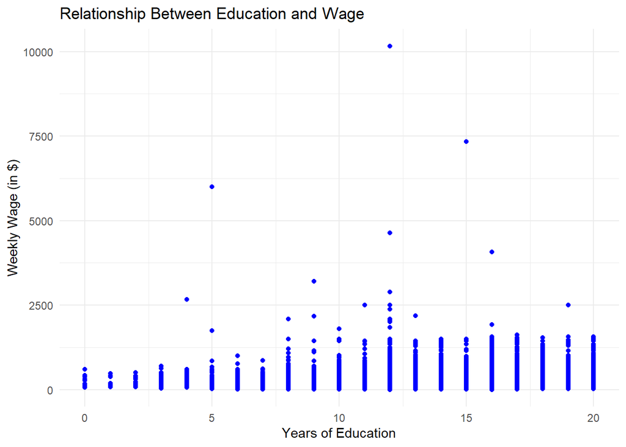

# **3.Estimate the baseline Specification**

```r
#linear model
linear_model1=lm(WAGE~ EDUC + AGE + RACE + SMSA + MARRIED + REGION2 + REGION3
                 + REGION4 + REGION5 + REGION6 + REGION7 + REGION8 + REGION9  , data = df)
```

```
##
## ==========================================================
##                              Dependent variable:
##                     --------------------------------------
##                                      WAGE
## ----------------------------------------------------------
## EDUC                              26.696***
##                                    (0.869)
##                                   t = 30.724
##                                   p = 0.000
## AGE                                2.244**
##                                    (0.942)
##                                   t = 2.382
##                                   p = 0.018
## RACE                              -77.632***
##                                    (10.225)
##                                   t = -7.592
##                                   p = 0.000
## SMSA                              -63.756***
##                                    (7.393)
##                                   t = -8.624
##                                   p = 0.000
## MARRIED                           78.001***
##                                    (8.026)
##                                   t = 9.719
##                                   p = 0.000
## REGION2                           41.193***
##                                    (13.644)
##                                   t = 3.019
##                                   p = 0.003
## REGION3                           49.088***
##                                    (13.305)
##                                   t = 3.690
##                                   p = 0.0003
## REGION4                             18.845
##                                    (15.600)
##                                   t = 1.208
##                                   p = 0.228
## REGION5                             4.205
##                                    (13.492)
```

[output cut: 15 more lines]

```
##                                    (14.046)
##                                   t = 4.536
##                                  p = 0.00001
## Constant                           -81.669*
##                                    (46.614)
##                                   t = -1.752
##                                   p = 0.080
## ----------------------------------------------------------
## Observations                        10,000
## R2                                  0.134
## Adjusted R2                         0.133
## Residual Std. Error          275.029 (df = 9986)
## F Statistic         118.953*** (df = 13; 9986) (p = 0.000)
## ==========================================================
## Note:                          *p<0.1; **p<0.05; ***p<0.01
```

### **3.1 Interpretation of the estimated Coefficient**

EDUC (26.696, p < 0.001)

A one-year increase in education leads to a $26.696 increase in weelky wages. This is highly significant (p = 0.000).

Regional Effects on Wages

Non-Significant Regions: REGION4, REGION5, REGION6, REGION7, REGION8 (p > 0.05) These regions do not significantly differ from the reference region in terms of wages.

|  | Res.Df | RSS | Df | Sum of Sq | F | Pr(>F) |
| --- | --- | --- | --- | --- | --- | --- |
| 1 | 9990 | 773577022 | NA | NA | NA | NA |
| 2 | 9986 | 755352847 | 4 | 18224175 | 60.23232 | 2.388944e-50 |

The joint significance test shows that AGE, RACE, MARRIED, and SMSA jointly contribute significantly to explaining WAGE. The F-statistic is 60.23 with a p-value < 2.2e-16, indicating strong statistical significance. We reject the null hypothesis that these four variables have no joint effect on wages.

|  | Res.Df | RSS | Df | Sum of Sq | F | Pr(>F) |
| --- | --- | --- | --- | --- | --- | --- |
| 1 | 9994 | 759957235 | NA | NA | NA | NA |
| 2 | 9986 | 755352847 | 8 | 4604388 | 7.608931 | 3.389338e-10 |

Since the p-value is extremely small (<0.001), we reject the null hypothesis. This means that at least one of the region coefficients is significantly different from zero, implying that region does have a statistically significant effect on wages.

# **4. Evaluating Gauss-Markov Assumptions and Applying Remedial Measures**

#### **4a. Stochastic Regressors**

All the variables are stochastic.

Strictly exogenous: AGE, RACE, QOB - These variables are fixed and not influenced by wages or the error term.

Weakly exogenous: SMSA, REGION - These variables may be correlated with unobserved factors affecting wages, but are not directly influenced by wages.

Endogenous: EDUC, MARRIED - Potential for reverse causality or correlation with the error term (e.g., higher wages → more education or higher likelihood of marriage).

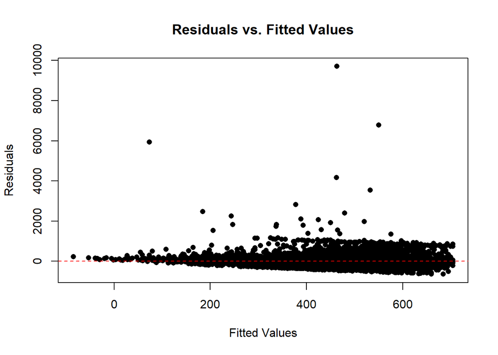

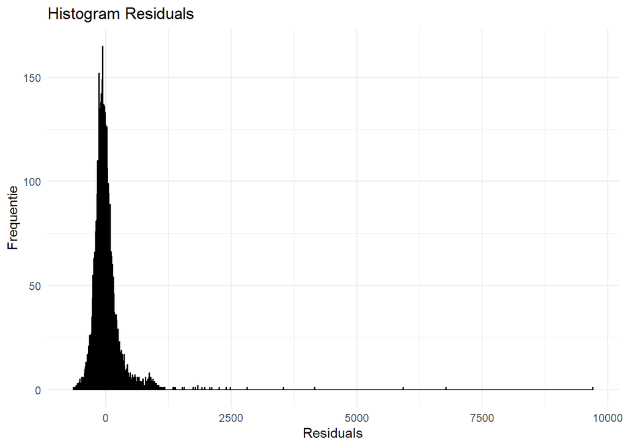

#### **4b. Normality Error Terms**

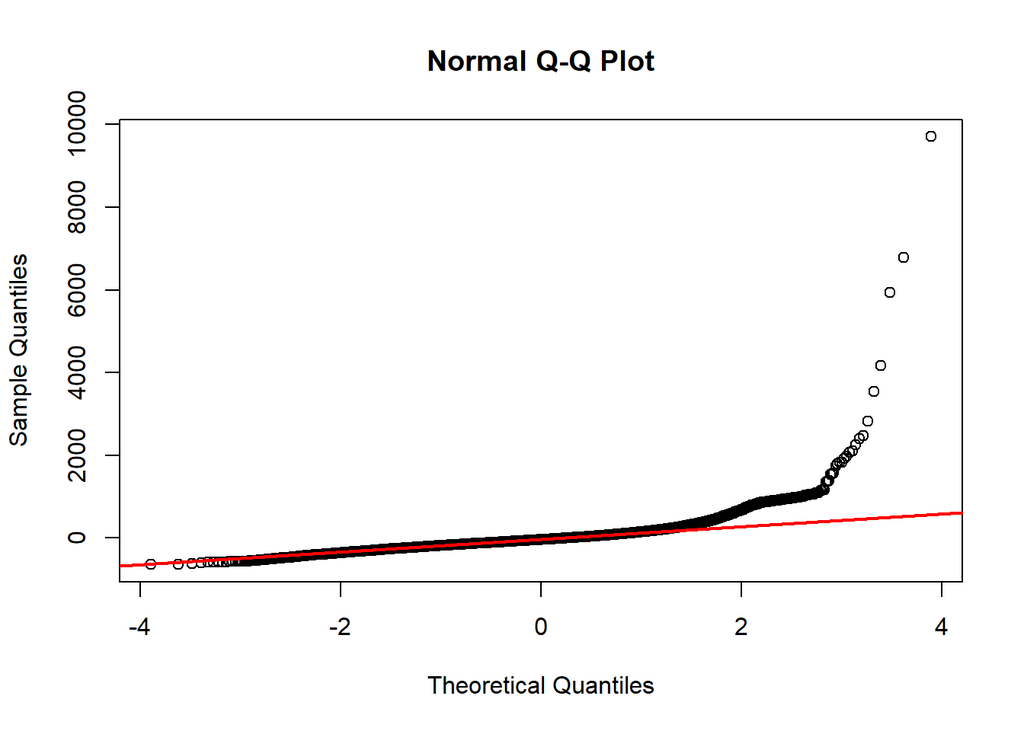

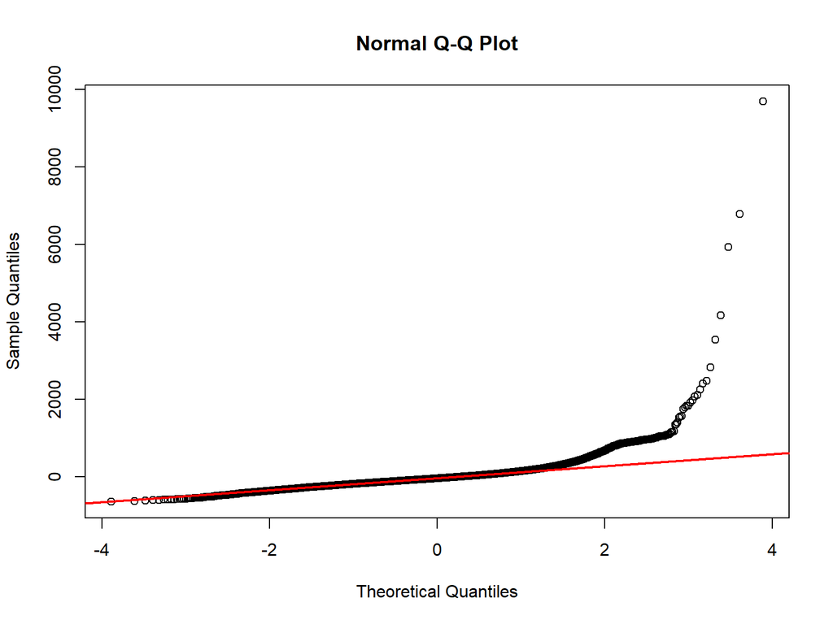

```
Jarque Bera Test
```

data: residuals X-squared = 21722226, df = 2, p-value < 2.2e-16

Since the p value is small, we reject the null hypothesis. Therefore the residuals are NOT normally distributed.

Implications for OLS:

1. Unbiasedness: Non-normal residuals do not affect the unbiasedness of OLS estimators as long as key assumptions (like linearity, exogeneity of regressors, and zero-mean error term) are satisfied.
2. Efficiency: OLS estimators may lose their efficiency because normality of residuals is necessary for OLS to be the Best Linear Unbiased Estimator (BLUE) under the Gauss-Markov assumptions.
3. Hypothesis Testing: The validity of tests (e.g., t-tests and F-tests) and confidence intervals relies on the normality assumption. Non-normal residuals can lead to incorrect p-values.
4. Heteroscedasticity or Outliers: Non-normality can signal issues like heteroscedasticity (non-constant error variance), the presence of outliers, or omitted variable bias.

###**Gauss-Markov assumptions**:

Assumption 1: Linearity in the parameters: CHECK

Assumption 2a: The X -values are fixed over repeated sampling (fixed regressor model) FAIL

Correlation between explanatory variables and error terms:

```r
print(mean(residuals))
```

```
## [1] -4.605628e-16
```

```r
print(t.test(residuals, mu = 0))
```

```
##
##  One Sample t-test
##
## data:  residuals
## t = -1.6757e-16, df = 9999, p-value = 1
## alternative hypothesis: true mean is not equal to 0
## 95 percent confidence interval:
##  -5.387624  5.387624
## sample estimates:
##     mean of x
## -4.605628e-16
```

```r
if (show_interpretation) {
  cat("Assumption 3: The expected V value of the error terms is zero: CHECK")
}
```

```
## Assumption 3: The expected V value of the error terms is zero: CHECK
```

### **4(d) Heteroskedasticity**

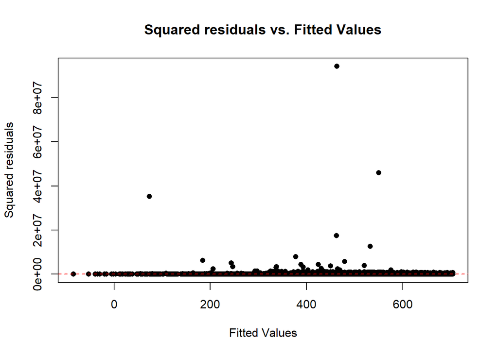

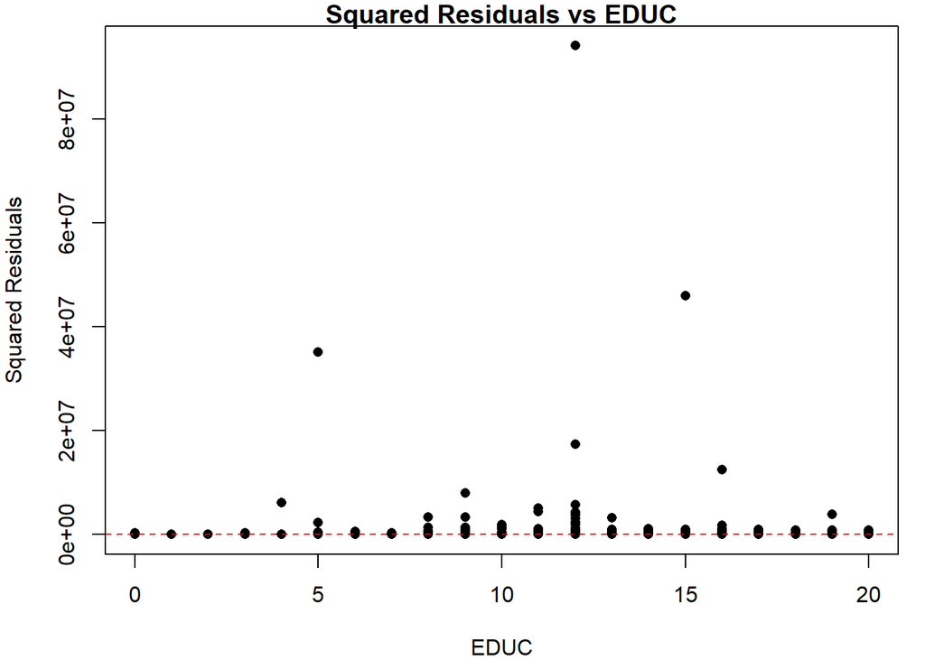

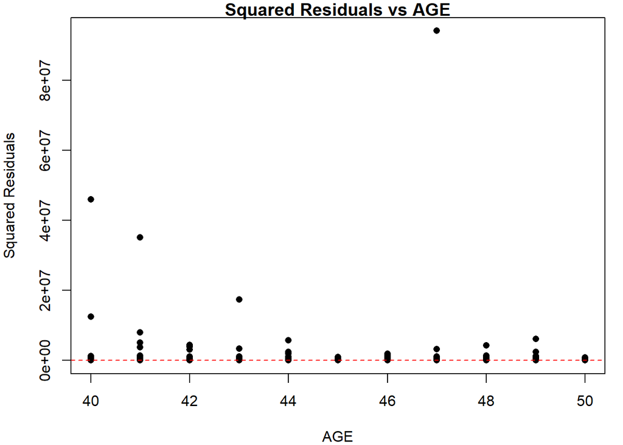

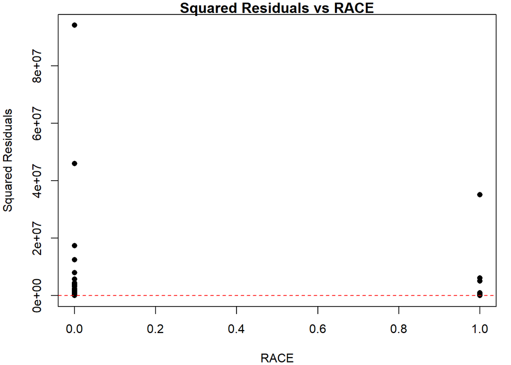

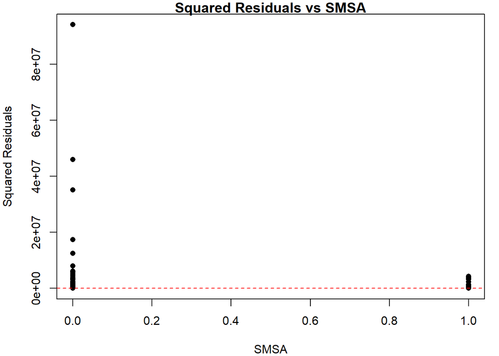

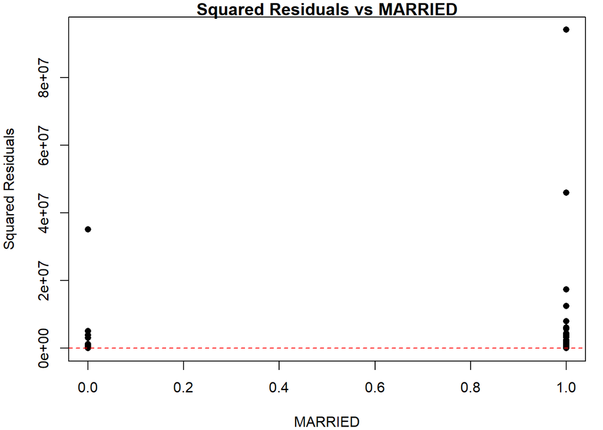

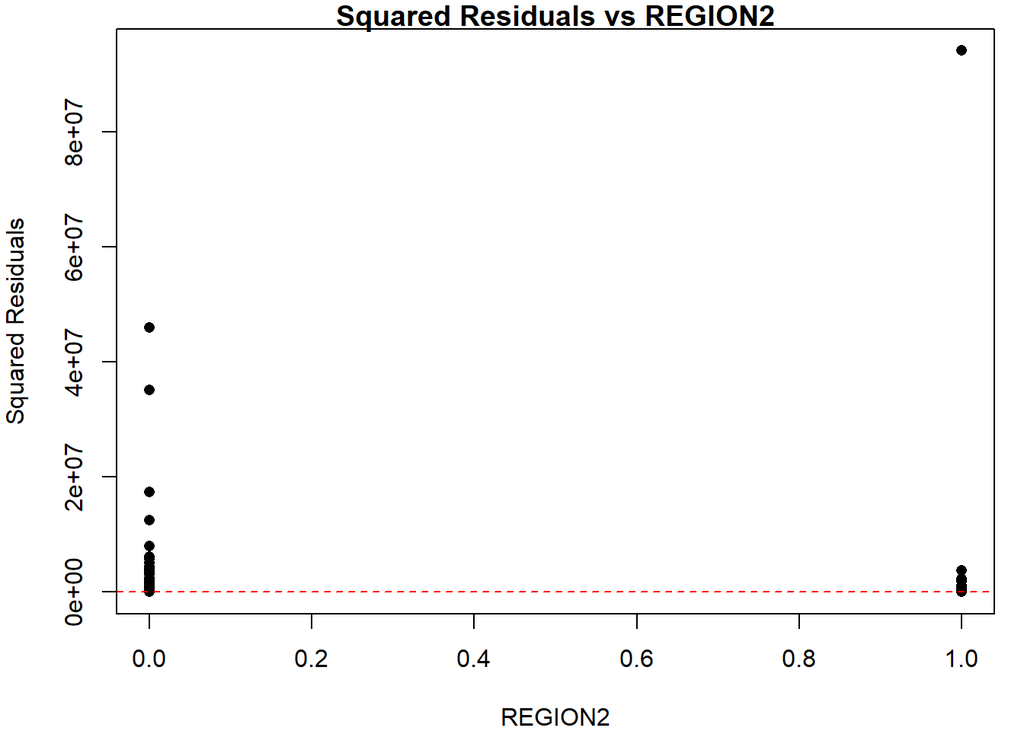

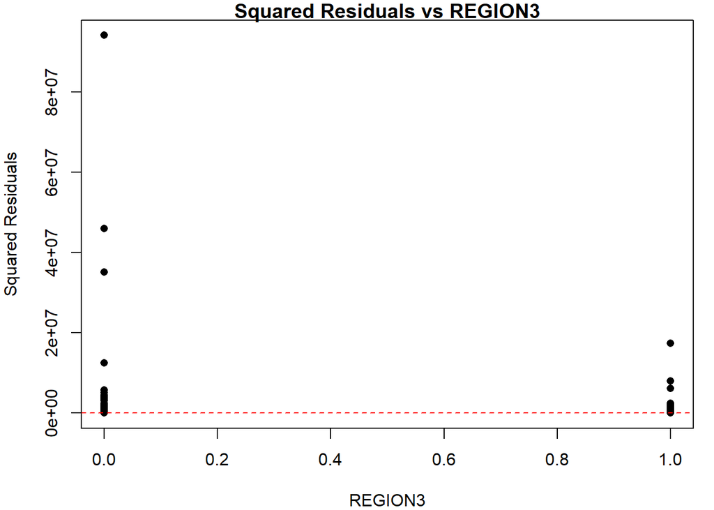

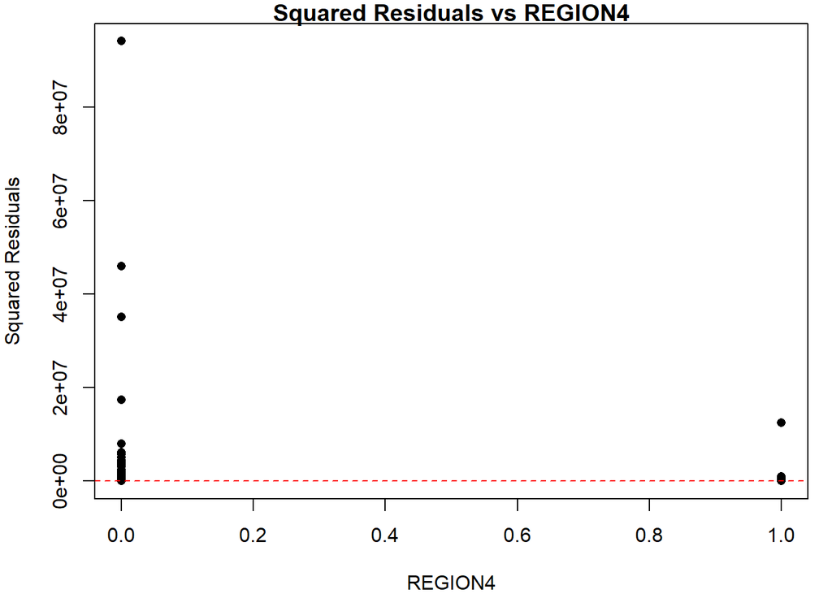

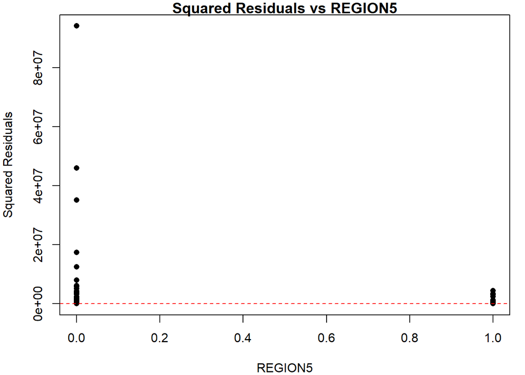

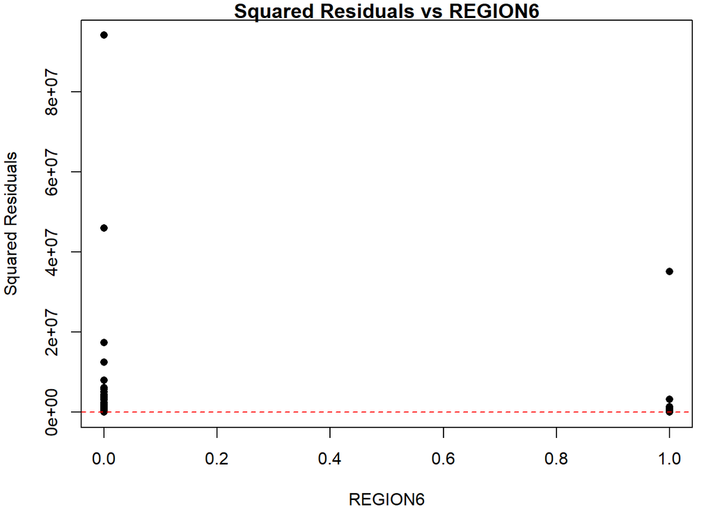

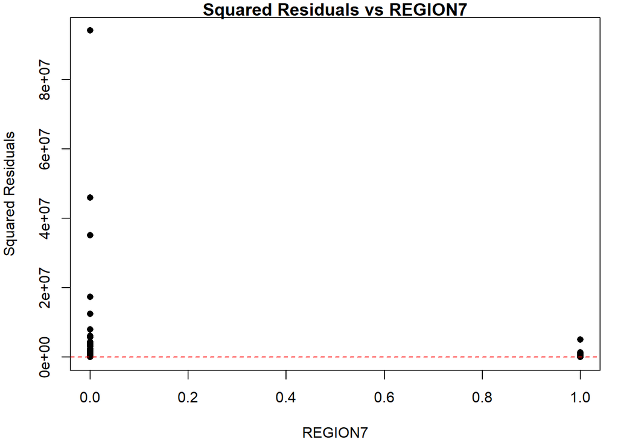

[2 more figures not shown]

### Interpretation of Residual Plots:

1. **Fitted Values**:
   - Slight increase in spread as fitted values increase
   - This pattern indicates potential heteroskedasticity
2. **EDUC**:
   - Initial increase followed by decrease in spread
   - Non-constant variance pattern visible
3. **RACE**:
   - Larger spread observed for white participants
   - Unequal variance between groups
4. **SMSA**:
   - Non-metropolitan areas show greater spread
   - Variance differs by urban/rural classification
5. **MARRIED**:
   - Similar variance pattern as other categorical variables
6. **REGION**:
   - Different spreads observed across regions (0-1 range)
   - Geographic heterogeneity in variance

**Conclusion**:

Clear signs of heteroskedasticity across multiple predictors, suggesting violations of the constant variance assumption.

## **4(d).1**Heteroskedasticity test **

#### **white’s general test**

```r
white_test <- bptest(linear_model1, ~ fitted(linear_model1) + I(fitted(linear_model1)^2))
print(white_test)
```

```
studentized Breusch-Pagan test
```

data: linear_model1 BP = 7.0287, df = 2, p-value = 0.02977

the p value of 0.02977 says that we reject the null hyptothis , which implies that we reject homoskedastiscity

**properties**

-for white there are not properties

#### **goldfeld-quant test**

```r
gqtest_result <- gqtest(linear_model1)
print(gqtest_result)
```

```
Goldfeld-Quandt test
```

data: linear_model1 GQ = 1.1763, df1 = 4986, df2 = 4986, p-value = 5.067e-09 alternative hypothesis: variance increases from segment 1 to 2

the p value of p-value = 5.067e-09 says that we strongly reject the null hyptothis , which implies that we reject homoskedastiscity

**properties**

-You split the dataset into two non-overlapping groups (dropping middle observations).

-Errors are normally distributed. **Implications for OLS Estimators**

-the coef( the betas ) are not normally distr in small samples

-var of the coef changes , we have a more robust variance formula if we use OLS

-OLS is no longer effecient , we use UGLS wich has a lower variance of the estimator

-the st errors of the coef are underestimated and are not to be trusted, therefore infernce bout the significance is wrong ## **4(d).2 adressing heteroskedasticity**

**OLS Regression with Robust Standard Errors**

|  | *Dependent variable:* |
| --- | --- |
|  | Weekly Wage |
| Education | 26.6959*** |
|  | (0.9195) |
| Age | 2.2442** |
|  | (0.9904) |
| Race (1=Black) | -77.6318*** |
|  | (9.3993) |
| SMSA | -63.7562*** |
|  | (6.2933) |
| Married | 78.0013*** |
|  | (7.9377) |
| Region 2 | 41.1931*** |
|  | (12.5820) |
| Region 3 | 49.0879*** |
|  | (10.7642) |
| Region 4 | 18.8453 |
|  | (12.9618) |
| Region 5 | 4.2049 |
|  | (10.9000) |
| Region 6 | 7.6044 |
|  | (15.3990) |
| Region 7 | 17.0805 |
|  | (12.0089) |
| Region 8 | 15.8968 |
|  | (13.7353) |
| Region 9 | 63.7105*** |
|  | (13.0419) |
| Constant | -81.6693 |
|  | (49.8668) |
| Observations | 10,000 |
| R<sup>2</sup> | 0.1341 |
| Adjusted R<sup>2</sup> | 0.1330 |
| Residual Std. Error | 275.0294 (df = 9986) |
| F Statistic | 118.9531*** (df = 13; 9986) |
| *Note:* | p<0.1; p<0.05; p<0.01 |
|  | Heteroskedasticity-consistent standard errors in parentheses |

##### **Interpretation:

**EGLS**

```r
gls_model <- gls(WAGE~ EDUC + AGE + RACE + SMSA + MARRIED + REGION2 + REGION3
                 + REGION4 + REGION5 + REGION6 + REGION7 + REGION8 + REGION9  , data = df)
                 weights = varIdent(form = ~1 | group_var)
```

**EGLS Estimation Results**

|  | *Dependent variable:* |
| --- | --- |
|  | Weekly Wages |
| Education | 26.696*** (0.869) |
| Age | 2.244** (0.942) |
| Race (1=Black) | -77.632*** (10.225) |
| SMSA | -63.756*** (7.393) |
| Married | 78.001*** (8.026) |
| Region 2 | 41.193*** (13.644) |
| Region 3 | 49.088*** (13.305) |
| Region 4 | 18.845 (15.600) |
| Region 5 | 4.205 (13.492) |
| Region 6 | 7.604 (16.123) |
| Region 7 | 17.081 (14.646) |
| Region 8 | 15.897 (17.106) |
| Region 9 | 63.710*** (14.046) |
| Constant | -81.669* (46.614) |
| Observations | 10,000 |
| Log Likelihood | -70,312.600 |
| Akaike Inf. Crit. | 140,655.200 |
| Bayesian Inf. Crit. | 140,763.300 |
| *Note:* | p<0.1; p<0.05; p<0.01 |
|  | Standard errors in parentheses |

##### **Comparison with Robust Standard Errors:**

[output not shown]

[output not shown]

```r
print(max(abs(correlation_matrix)))
```

```
## [1] 1
```

```r
print('VIF values')
```

```
## [1] "VIF values"
```

```r
vif_values = vif(linear_model1)
print(vif_values)
```

```
##     EDUC      AGE     RACE     SMSA  MARRIED  REGION2  REGION3  REGION4
## 1.072047 1.008200 1.054291 1.072522 1.019728 3.280936 3.672041 2.182705
##  REGION5  REGION6  REGION7  REGION8  REGION9
## 3.510183 2.058605 2.540830 1.816650 2.919060
```

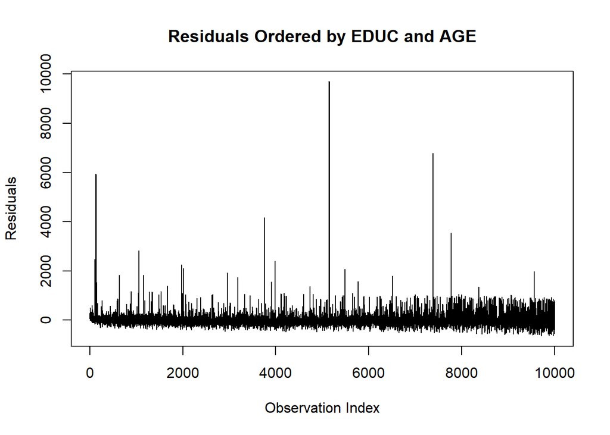

```r
df$residuals <- residuals
df_ordered <- df[order(df$EDUC, df$AGE), ]
plot(df_ordered$residuals, type = "l",
     main = "Residuals Ordered by EDUC and AGE",
     ylab = "Residuals", xlab = "Observation Index")
```

```r
runs.test(df$residuals)
```

```
##
##  Runs Test
##
## data:  df$residuals
## statistic = -0.22001, runs = 4990, n1 = 5000, n2 = 5000, n = 10000,
## p-value = 0.8259
## alternative hypothesis: nonrandomness
```

```r
if (show_interpretation) {
  cat("Assumptions:
  1) no need to assume specific error structure
  2) The observations should be in a meaningful order as the test evaluates the sequence
  High p-value suggest that there is no autocorrelation.")
  }
```

```
## Assumptions:
##   1) no need to assume specific error structure
##   2) The observations should be in a meaningful order as the test evaluates the sequence
##   High p-value suggest that there is no autocorrelation.
```

```r
DW=dwtest(linear_model1)
# print to screen
DW_summary=c(DW$statistic,DW$p.value)
names(DW_summary)=c("Test-statistic","P-value")
stargazer(DW_summary,type="text")
```

```
##
## ======================
## Test-statistic P-value
## ----------------------
## 2.010           0.691
## ----------------------
```

```r
if (show_interpretation) {
  cat("Assumptions:
  1) Error terms follow an AR(1) process
  2) Error terms are normally distributed
  3) The regression model does not include lagged dependent variables
  High p-value suggest that there is no autocorrelation.")
  }
```

```
## Assumptions:
##   1) Error terms follow an AR(1) process
##   2) Error terms are normally distributed
##   3) The regression model does not include lagged dependent variables
##   High p-value suggest that there is no autocorrelation.
```

```r
BG = bgtest(linear_model1, order = 6)  # Change order as needed
BG_summary=c(BG$statistic,BG$p.value)
names(BG_summary)=c("Test-statistic","P-value")
stargazer(BG_summary,type="text")
```

```
##
## ======================
## Test-statistic P-value
## ----------------------
## 5.488           0.483
## ----------------------
```

```r
if (show_interpretation) {
  cat("Assumptions:
  1) Allows for stochastic regressors
  2) Tests for higher-order autocorrelation
  3) Allows for lagged dependent variables
  High p-value suggest that there is no autocorrelation.")
  }
```

```
## Assumptions:
##   1) Allows for stochastic regressors
##   2) Tests for higher-order autocorrelation
##   3) Allows for lagged dependent variables
##   High p-value suggest that there is no autocorrelation.
```

```r
if (show_interpretation) {
  cat("Implications for OLS if autocorrelation is present:
  1) Standard variance formula is incorrect
  2) OLS estimator no longer efficient")
  cat("Inference: Standard errors are incorrect, leading to invalid t-tests, F-tests, and confidence intervals")
  cat("It does not make sense to interpret autocorrelation as a structural feature since there is no natural ordering for the dataset.")
  }
```

```
## Implications for OLS if autocorrelation is present:
##   1) Standard variance formula is incorrect
##   2) OLS estimator no longer efficientInference: Standard errors are incorrect, leading to invalid t-tests, F-tests, and confidence intervalsIt does not make sense to interpret autocorrelation as a structural feature since there is no natural ordering for the dataset.
```